# EXAMEN_PARCIAL

## PRIMERA PARTE

1.1 Se tiene una variable x (no necesariamente temperatura) que depende de la elevaci´on. Se sabe que entre los 1000 y 3000 metros, esta variable se ve reducido en 2 unidades cada 500 metros. Entre los 3000 y 4000 metros, var´ıa en 0.5 unidades, y a una altitud mayor, su valor es constante. Cree una funci´on que permita obtener el valor de esta variable, ´unicamente con el dato de la elevaci´on. [2pts]

El valor de la variable x a 1000 metros es de 81.4 unidades

```r
variable <- function(altitud, x = 85.4) {
  if (altitud >= 1000 & altitud < 3000) {
    p = x  - 2*(altitud %/% 500)
  } else if (altitud >= 3000 & altitud < 4000) {
    p = x - 0.5 * (altitud %/% 500)
  } else if (altitud >= 4000) {
    p = x
  } else {
    print("valor no considerado")
  }

  return(p)
}

variable(1000)
```

```
## [1] 81.4
```

1.2 Resolver el siguiente sistema de ecuaciones

```r
A <- c(3, 2, 1, 2, -1, 4, -2, 3, 2)
B <- c(0, 9, -4)

ecuacion1 <- matrix(A, ncol = 3)
ecuacion2 <- matrix(B, ncol = 1)

solve(ecuacion1, ecuacion2)
```

```
##      [,1]
## [1,]    2
## [2,]   -2
## [3,]    1
```

## SEGUNDA PARTE

1 A partir del siguiente **conjunto de datos**, se describen las variables:

uh name → Nombre de cuenca

bh esc → Escenario (observado y modelos climáticos)

bh month → Meses

bh pc → Precipitación

bh er → Evapotranspiración Real

bh rh → Rendimiento Hídrico

bh qd → Caudal Se solicita lo siguiente:

A: Calcular la precipitaci´on acumulada anual (Valores observados) para la cuenca asignada

```r
library(dplyr)
library(readr)

datos <- read_csv("mods_clima_uh.csv")

(datos <- datos %>%
  filter(
    uh_name == "Cuenca Tumbes"
  ) %>%
  select(
    bh_month, everything()
  ))
```

```
## # A tibble: 48 x 8
##    bh_month  code uh_name       bh_esc      bh_pc  bh_er bh_rh bh_qd
##       <dbl> <dbl> <chr>         <chr>       <dbl>  <dbl> <dbl> <dbl>
##  1        1  1394 Cuenca Tumbes Observado 108.    31.5    34.7  62.1
##  2        2  1394 Cuenca Tumbes Observado 182.    50.8    66.0 138.
##  3        3  1394 Cuenca Tumbes Observado 228.    79.1    98.2 190.
##  4        4  1394 Cuenca Tumbes Observado 199.    66.5   112.  225.
##  5        5  1394 Cuenca Tumbes Observado  39.0   23.5    74.6 157.
##  6        6  1394 Cuenca Tumbes Observado   8.39   7.10   46.1 102.
##  7        7  1394 Cuenca Tumbes Observado   1.11   1.89   33.3  69.6
##  8        8  1394 Cuenca Tumbes Observado   0.621  0.927  23.7  48.1
##  9        9  1394 Cuenca Tumbes Observado   2.07   2.10   16.6  33.8
## 10       10  1394 Cuenca Tumbes Observado  13.4   10.5    13.4  25.3
## # ... with 38 more rows
```

```r
(observado <- datos %>%
  group_by(bh_esc) %>%
  summarise(
    bh_pc = sum(bh_pc, na.rm = T)
  ) %>%
  filter(
    bh_esc == "Observado"
  ))
```

```
## # A tibble: 1 x 2
##   bh_esc    bh_pc
##   <chr>     <dbl>
## 1 Observado  852.
```

B: Calcular el porcentaje de sesgo (%, PBIAS) de los escenarios clim´aticos (ACCESS, HADGEM2, MPI) respecto a los datos observados para cada mes (enero - diciembre) de cada variable, para la cuenca asignada.

```r
models <- c("ACCESS 1.0", "HadGEM2-ES", "MPI-ESM-LR", "Observado")
model <- data.frame(month.abb)

for (i in 1:4) {
  valor = datos %>%
    filter(bh_esc == models[i]) %>%
    select(bh_pc)
  model = cbind(model, valor)
}
colnames(model) <- c("meses", "ACCESS 1.0", "HadGEM2-ES", "MPI-ESM-LR", "Observado")
model
```

```
##    meses  ACCESS 1.0 HadGEM2-ES  MPI-ESM-LR   Observado
## 1    Jan 189.2583333 105.837346  88.1949074 107.7222222
## 2    Feb 225.4086420 220.649691 233.2955247 181.9952160
## 3    Mar 292.5112654 243.724383 229.8470679 227.9540123
## 4    Apr 218.3214506 227.314815 147.6195988 199.0138889
## 5    May  32.2145062  66.484877  33.0645062  38.9842593
## 6    Jun   7.5817901  11.830093   4.0831790   8.3944444
## 7    Jul   2.6816358   3.530093   0.8430556   1.1098765
## 8    Aug   0.4733025   0.833642   0.4631173   0.6212963
## 9    Sep   2.0527778   1.823611   1.5904321   2.0683642
## 10   Oct  24.0435185  13.033488  19.2908951  13.3933642
## 11   Nov  28.2643519  26.832253  37.1898148  28.1310185
## 12   Dec  49.8966049  47.191204  43.3859568  42.4638889
```

```r
sesgo <- model %>%
  mutate(
    SESGO_ACCESS = (abs(`ACCESS 1.0` - Observado)/Observado)*100,
    SESGO_HADGEM2 = (abs(`HadGEM2-ES` - Observado)/Observado)*100,
    SESGO_MPI = (abs(`MPI-ESM-LR` - Observado)/Observado)*100
  )
sesgo
```

```
##    meses  ACCESS 1.0 HadGEM2-ES  MPI-ESM-LR   Observado SESGO_ACCESS
## 1    Jan 189.2583333 105.837346  88.1949074 107.7222222   75.6910779
## 2    Feb 225.4086420 220.649691 233.2955247 181.9952160   23.8541578
## 3    Mar 292.5112654 243.724383 229.8470679 227.9540123   28.3202969
## 4    Apr 218.3214506 227.314815 147.6195988 199.0138889    9.7016152
## 5    May  32.2145062  66.484877  33.0645062  38.9842593   17.3653501
## 6    Jun   7.5817901  11.830093   4.0831790   8.3944444    9.6808589
## 7    Jul   2.6816358   3.530093   0.8430556   1.1098765  141.6156841
## 8    Aug   0.4733025   0.833642   0.4631173   0.6212963   23.8201689
## 9    Sep   2.0527778   1.823611   1.5904321   2.0683642    0.7535626
## 10   Oct  24.0435185  13.033488  19.2908951  13.3933642   79.5181417
## 11   Nov  28.2643519  26.832253  37.1898148  28.1310185    0.4739726
## 12   Dec  49.8966049  47.191204  43.3859568  42.4638889   17.5036160
##    SESGO_HADGEM2 SESGO_MPI
## 1       1.749756 18.127471
## 2      21.239281 28.187724
## 3       6.918225  0.830455
## 4      14.220578 25.824474
## 5      70.542875 15.184983
## 6      40.927642 51.358556
## 7     218.061735 24.040601
## 8      34.177844 25.459513
## 9      11.833172 23.106767
## 10      2.686977 44.033230
## 11      4.616845 32.202162
## 12     11.132553  2.171417
```

C: De la pregunta anterior, ¿Cu´al es el escenario clim´atico m´as preciso? Fundamente su respuesta

```r
sesgo1 <- sesgo %>%
  summarise(
    SESGO_ACCESS = mean(SESGO_ACCESS, na.rm = T),
    SESGO_HADGEM2 = mean(SESGO_HADGEM2, na.rm = T),
    SESGO_MPI = mean(SESGO_MPI, na.rm = T)
  )
sesgo1
```

```
##   SESGO_ACCESS SESGO_HADGEM2 SESGO_MPI
## 1     35.69154      36.50896  24.21061
```

Comentario: Como se puede observar, el modelo MPI-ESM-LR tiene un menor promedio por tanto, es el modelo con más precision.

D: Graficar, con ggplot2, la precipitaci´on (enero a diciembre) observada y modelos clim´aticos.

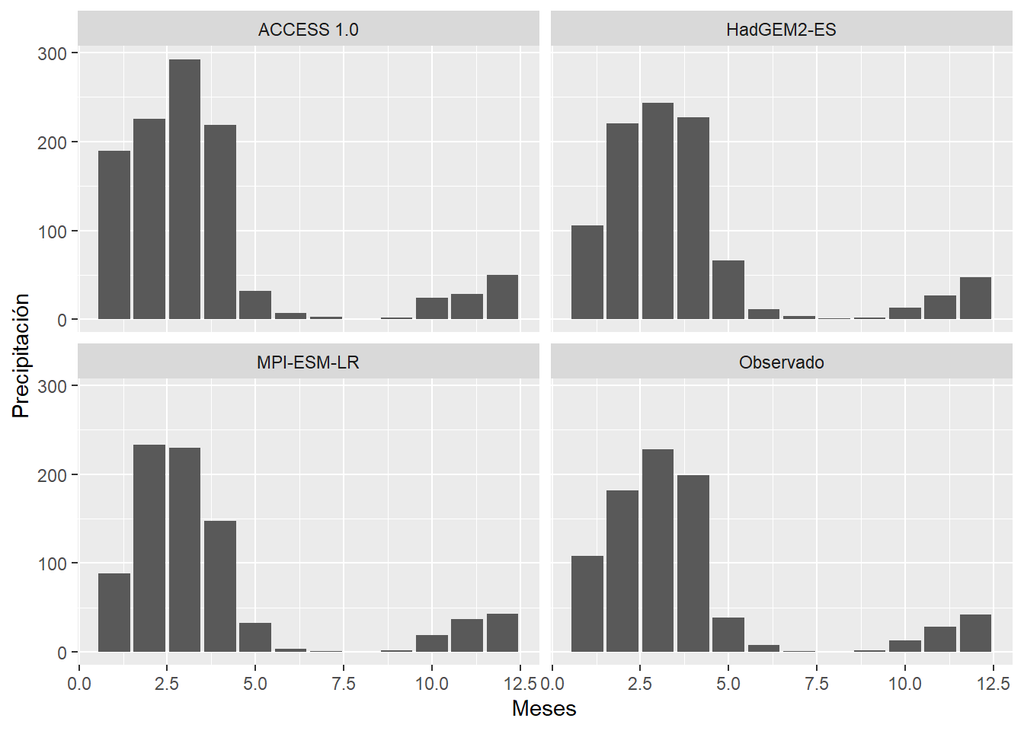

```r
library(ggplot2)
ggplot(datos) +
  geom_bar(mapping = aes(x = bh_month, y = bh_pc), stat = "identity") +
  facet_wrap(~bh_esc) +
  labs(x = "Meses", y = "Precipitación")
```

## TERCERA PARTE

1: Se tiene el conjunto de datos de temperatura diaria (per´ıodo 1928 - 2015) de ciertas estaciones meteorolÓgicas (temperatureDataset.csv), donde cada una de estas est´an asociadas a un c´odigo ´unico (p.e. qc00000208). Si existen valores iguales a -99.9, considerarlos como missing values y convertirlos a NA.

```r
Data03 <- read_csv("temperatureDataset.csv")
Data_temp <- Data03 %>%
  select(DATE, all_of("qc00000746")) %>%
  rename(
    Temp = qc00000746
  ) %>%
   mutate(
    DATE = as.Date(DATE, format("%d/%m/%Y")),
    Temp = ifelse(Temp == -99.9, NA, Temp)
  ) %>%
  arrange()
```

- Evaluamos si la data está completa:

```r
tail(Data_temp)
```

```
## # A tibble: 6 x 2
##   DATE        Temp
##   <date>     <dbl>
## 1 2015-10-26    NA
## 2 2015-10-27    NA
## 3 2015-10-28    NA
## 4 2015-10-29    NA
## 5 2015-10-30    NA
## 6 2015-10-31    NA
```

```r
seq(as.Date("1928-11-02"), as.Date("2015-10-31"), by = "day") %>% length()
```

```
## [1] 31775
```

COMENTARIO: Como se puede observar la data es completa con ello ahora si podemos empezar a manipular

A: Determine la cantidad de missing values para los a˜nos hidrol´ogicos Sep1983-Agos1984 y Sep1997- Agos1998.

```r
funcion_temp <- function(m, n){

  Data_temp %>% filter(
    DATE >= m & DATE <= n
  ) %>%
  mutate(
    cantidad_NAs = sum(is.na(Temp))
  ) %>%
  summarise(
    cantidad_NAs = unique(cantidad_NAs)
  )
}
funcion_temp("1983-09-01", "1984-08-31")
```

```
## # A tibble: 1 x 1
##   cantidad_NAs
##          <int>
## 1            1
```

```r
funcion_temp("1997-09-01", "1998-08-31")
```

```
## # A tibble: 1 x 1
##   cantidad_NAs
##          <int>
## 1            2
```

B: Calcule la serie de tiempo de temperatura mensual (si el de d´ıas con missing values, en un mes, supera el 5%, la temperatura mensual ser´a considerado como un NA). Adem´as, identifique, visualmente, posibles valores at´ıpicos y describa una posible causa

```r
library(stringr)
Tem_mensual <- Data_temp %>%
  group_by(DATE = str_sub(DATE, 1, 7)) %>%
  mutate(
    valores_NAs = sum(is.na(Temp))*100/ n()
  ) %>%
  summarise(
    Temp = mean(Temp, na.rm = T),
    valores_NAs = unique(valores_NAs)
  ) %>%
  mutate(
    Temp = ifelse(valores_NAs > 5, NA, Temp),
    DATE = as.Date(sprintf("%1$s-01", DATE))
  )
Tem_mensual
```

```
## # A tibble: 1,044 x 3
##    DATE        Temp valores_NAs
##    <date>     <dbl>       <dbl>
##  1 1928-11-01    NA         100
##  2 1928-12-01    NA         100
##  3 1929-01-01    NA         100
##  4 1929-02-01    NA         100
##  5 1929-03-01    NA         100
##  6 1929-04-01    NA         100
##  7 1929-05-01    NA         100
##  8 1929-06-01    NA         100
##  9 1929-07-01    NA         100
## 10 1929-08-01    NA         100
## # ... with 1,034 more rows
```

Comentario : Ahora para poder identificar de una mejor manera podemos graficarlo como se muestra a continuación

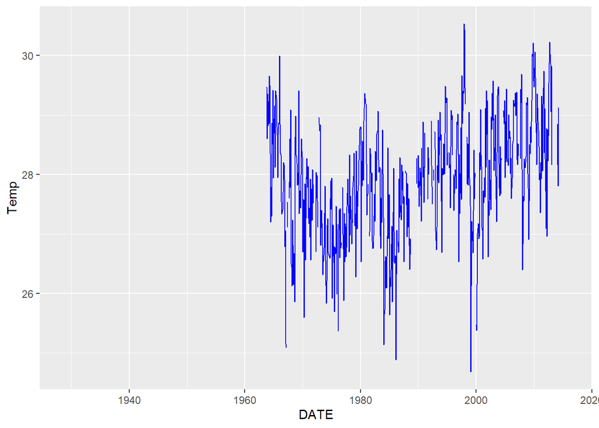

```r
ggplot(Tem_mensual, aes(DATE, Temp)) +
  geom_line(color = "blue" )
```

C: Determine la cantidad de missing values de la serie de tiempo a paso mensual para los a˜nos 2005 y 2010

```r
mensual_NA <- Tem_mensual %>%
  filter(DATE >= "2005-01-01" & DATE <= "2010-12-01") %>%
  mutate(
    valores_NAs = sum(is.na(Temp)),
  ) %>%
  summarise(
    valores_NAs = unique(valores_NAs)
  )

mensual_NA
```

```
## # A tibble: 1 x 1
##   valores_NAs
##         <int>
## 1           1
```

D: Cree una funci´on que calcule, a partir de los datos de temperatura mensual, la climatolog´ıa (Ene-Dic). Obtener la climatolog´ıa para los per´ıodos 1980-1995 y 1996-2010. Plotear sus resultados en una sola g´rafica para describir sus diferencias y/o similitudes (entre climatolog´ıas).

```r
funcion02 <- function(p, q){
  Tem_mensual %>%
  filter(DATE >= p & DATE <= q) %>%
  group_by(
    DATE = str_sub(DATE, 6, 7)
  ) %>%
  summarise(
    Temp = mean(Temp, na.rm = T)
  ) %>%
  mutate(
    periodo = sprintf("periodo %1$s-%2$s",
                      p = str_sub(p, 1, 4),
                      q = str_sub(q, 1, 4))
  )
}
Periodo01 <- funcion02("1980-01-01","1995-12-01")
Periodo02 <- funcion02("1996-01-01","2010-12-01")

grafico <- rbind(Periodo01, Periodo02)
grafico
```

```
## # A tibble: 24 x 3
##    DATE   Temp periodo
##    <chr> <dbl> <chr>
##  1 01     27.4 periodo 1980-1995
##  2 02     27.1 periodo 1980-1995
##  3 03     27.4 periodo 1980-1995
##  4 04     27.6 periodo 1980-1995
##  5 05     27.7 periodo 1980-1995
##  6 06     27.5 periodo 1980-1995
##  7 07     27.0 periodo 1980-1995
##  8 08     27.7 periodo 1980-1995
##  9 09     28.1 periodo 1980-1995
## 10 10     28.4 periodo 1980-1995
## # ... with 14 more rows
```

Comentario: como ya tenemos todo listo ahora lo podemos plotear

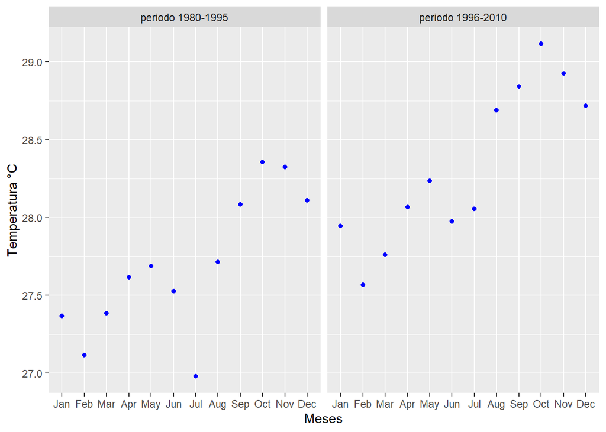

```r
ggplot(grafico, aes(DATE, Temp)) +
  geom_point(color ="blue") +
  facet_wrap(~periodo) +
  labs(x = "Meses", y = "Temperatura °C") +
  scale_x_discrete(
    labels = month.abb
  )
```